# Report CMSC 630 Project part 2: Image segmentation

Erick Calderon-Morales

**All functions can be found in the folder called image_segmentation_functions**

In your project report, please present example results before and after edge detection / dilation /erosion /segmentation for each respective class of cells (seven in total)

# 1 Use of the library h5py

Before running the analysis, all images where saved in a h5py binary data format. This was done with the python package called h5py. This procedure let me store the 499 images in 7 groups, corresponding to each one of the classes of cancer images presented in the original images tag name. The advantage of the procedure was that it lets store huge amounts of data that is easily manipulable with NumPy package. Also let you save the all the images into one single file.

For this procedure the function called *store_BMP_images_as_h5py.py* created the file called cancerous_cell_smears.hdf5.

The function images_to_hdf5(path1, path2) takes 2 arguments:

- path1: which is the path where the images are stored
- path2: with is the path where the h5py file will be stored.

```python
def images_to_hdf5(path1, path2):
    #This function takes the path where the images are, read them and save a
    # hdf5 file
    #Path2 where the hdf5 file will be saved

    # Create empty dictionary for storing images and ids
    images_dict = {}

    for file in glob.glob(f"{path1}/*.BMP"):

        #Get image id
        img_id = os.path.basename(file)

        #Read the image
        img = cv2.imread(file)

        #append key and value to dictionary
        images_dict[img_id] = img

    # Create a new HDF5 file
    file = h5py.File(f'{path2}/cancerous_cell_smears.hdf5', "w")

    # Create a dataset for each image stored in the h5py file
    for key, value in images_dict.items():

        #Type 1
        if 'cyl' in key:
            key = file.create_dataset(
                (f'class_cyl/image_{key}'), np.shape(value), h5py.h5t.STD_U8BE, data=value)
        #Type 2
        elif 'inter' in key:
            key = file.create_dataset(
                (f'class_inter/image_{key}'), np.shape(value), h5py.h5t.STD_U8BE, data=value)
        #Type 3
        elif 'let' in key:
            key = file.create_dataset(
                (f'class_let/image_{key}'), np.shape(value), h5py.h5t.STD_U8BE, data=value)
        #Type 4
        elif 'mod' in key:
            key = file.create_dataset(
                (f'class_mod/image_{key}'), np.shape(value), h5py.h5t.STD_U8BE, data=value)
        #Type 5
        elif 'para' in key:
            key = file.create_dataset(
                (f'class_para/image_{key}'), np.shape(value), h5py.h5t.STD_U8BE, data=value)
        #Type 6
        elif 'super' in key:
            key = file.create_dataset(
                (f'class_super/image_{key}'), np.shape(value), h5py.h5t.STD_U8BE, data=value)
        #Type 7
        elif 'svar' in key:
            key = file.create_dataset(
                (f'class_svar/image_{key}'), np.shape(value), h5py.h5t.STD_U8BE, data=value)

    #Prin how many images were read and id of each one
    print(f'\n{len(images_dict)} images were read:')
    for key in images_dict:
        print(f'\t- {key}')

    print(f'\nThe cancerous_cell_smears.hdf5 file was save on: ')
    print(f'\n{path2}')

#Test function-----------------------------------------------------------------
#path1= '~/image_analysis/project/part_1/cancerous_cell_smears_images'
#path2='~/image_analysis/project/part_1'
#images_to_hdf5(path1,path2)
```

# 2 Edge detection: Sobel algorithm

**Implement one selected edge detection algorithm.**

For the edge detection procedure, the sobel filter was used to create the function called sobel(). This function takes a gray scale image and returns a plot with the edges detected inside the image.

The function takes three arguments:

- img: Name of the array inside the h5py file .The names of the images follow the notation image_tag.BMP e.g. image_svar99.BMP
- direction: Direction that the filter will work e.g. on a vertical direction or a horizontal direction.
- path_h5py_file: Directory file path where a h5py file is stored locally.

This function was build following this [tutorial](https://www.pyimagesearch.com/2016/07/25/convolutions-with-opencv-and-python/)

```python
def sobel(img,direction, path_h5py_file = None):
    #Load h5py File
    hdf = h5py.File(f'{path_h5py_file}/cancerous_cell_smears.hdf5','r')
    for each_group in hdf:
        group = hdf.get(each_group)

        if img in set(group):
            img_array = np.array(group.get(img))[:,:,0]
            print(img_array)
            break

    global sobel_kernel
    #Create Kernels, Vertical and Horizontal
    if direction== "horizontal":

        sobel_kernel =  [[-1,0,1], [-2,0,2], [-1,0,1]] * (np.ones((int(3),int(3)), dtype="int"))
        #print(sobel_kernel)

    elif direction == "vertical":

        sobel_kernel = [[-1,-2,-1], [0,0,0], [1,2,1]] * (np.ones((int(3),int(3)), dtype="int"))
        #print(sobel_kernel)

    # grab the spatial dimensions of the image
    (i_height, i_width) = img_array.shape[:2]

    # grab the spatial dimensions of the kernel
    (k_height, k_width) = sobel_kernel.shape[:2]

    #replicating the pixels along the border of the image
    #IS PADDING NECESSARY?????
    pad = (k_width - 1) // 2

    #Load image
    image = cv2.copyMakeBorder(img_array, pad, pad, pad, pad,cv2.BORDER_REPLICATE)
    output = np.zeros((i_height, i_width), dtype="float32")

    # loop over the input image, sliding the kernel across
    # each (x, y)-coordinate from left-to-right and top to
    # bottom
    #“sliding” the kernel from left-to-right and top-to-bottom
    #1 pixel at a time.

    for y in np.arange(pad, i_height + pad):
        for x in np.arange(pad, i_width + pad):

            #Region of Interest (ROI)
            # # Extract the ROI of the image by extracting the
            # # *center* region of the current (x, y)-coordinates
            # # dimensions

            roi = image[y - pad:y + pad + 1, x - pad:x + pad + 1]

            # perform the actual convolution by taking the
            # # element-wise multiplicate between the ROI and
            # # the kernel, then summing the matrix

            k = (roi * sobel_kernel).sum()

            # store the convolved value in the output (x,y)-
            # # coordinate of the output image

            output[y - pad, x - pad] = k

    #rescale the output image to be in the range [0, 255]
    output = rescale_intensity(output, in_range=(0, 255))
    output = (output * 255).astype("uint8")

    # return the output image
    plt.title('Sobel X'), plt.xticks([]), plt.yticks([])
    plt.subplot(2,2,4),plt.imshow(output,cmap = 'gray')

#Test Function ------------------------------------------------------------------
#path_h5py = '~/part_2'
#sobel('image_cyl07.BMP', direction = "vertical", path_h5py_file = path_h5py  )
```

## 2.1 Results Edge detection

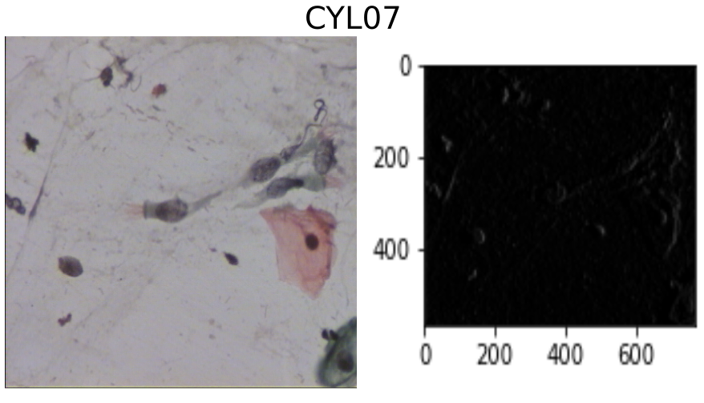

Compartion between original image (left) and result from the function (right)

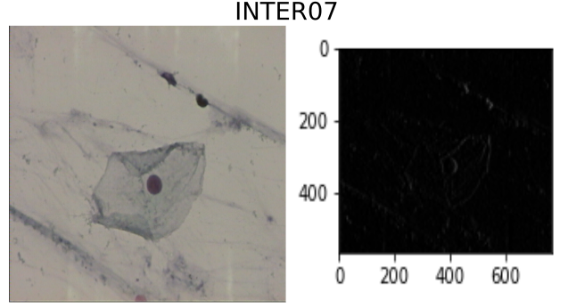

Compartion between original image (left) and result from the function (right)

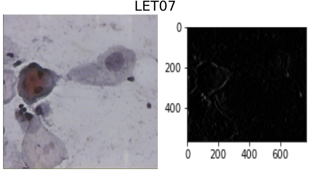

Compartion between original image (left) and result from the function (right)

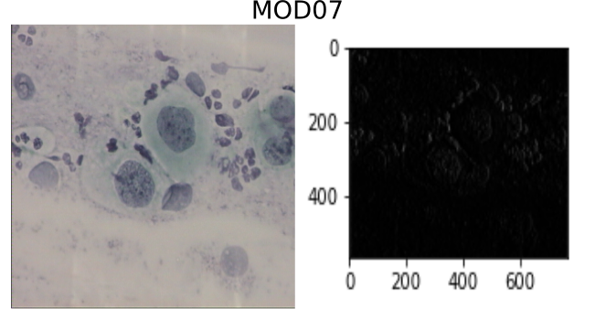

Compartion between original image (left) and result from the function (right)

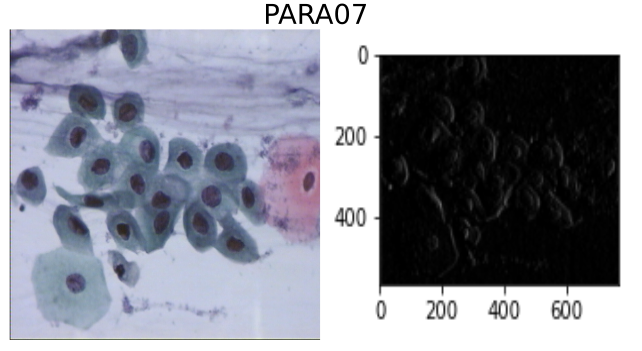

Compartion between original image (left) and result from the function (right)

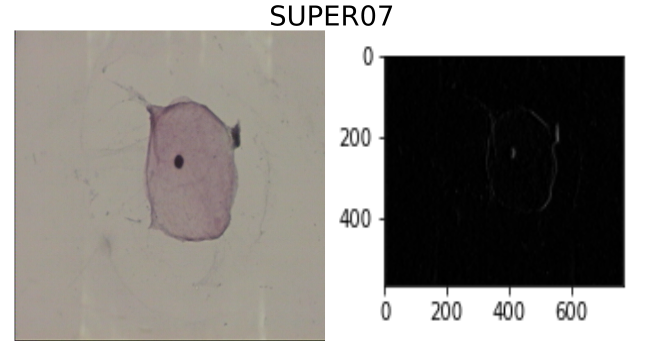

Compartion between original image (left) and result from the function (right)

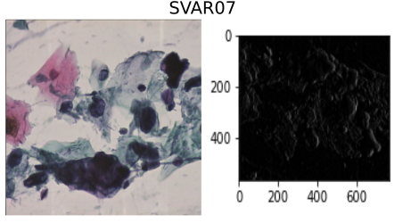

Compartion between original image (left) and result from the function (right)

# 3 Segmentation techniques

**Implement two segmentation techniques (they must be implemented by you,not API calls)**

## 3.1 Clustering: K-Means algorithm

**Clustering (k-means recommended, examine the effect of different values of k parameter on the segmentation)**

Before implementing the slow_k_means(), three other functions where created:

- get_closest_centroid(): Takes an input x and a list, centroids, and returns the index of the list centroids corresponding to the centroid closest to x.
- compute_l2_distance(): Takes two points and computes the L2 distance between them
- compute_sse(): Computes the Sum of Squared Errors which is used to decide how many iterations we have to do

This function was build following this [tutorial](https://blog.paperspace.com/speed-up-kmeans-numpy-vectorization-broadcasting-profiling/)

```python
#------------------------------------------------------------------------------
def get_closest_centroid(x, centroids):
        # Initialize the list to keep distances from each centroid
        centroid_distances = []

        # Loop over each centroid and compute the distance from data point.
        for centroid in centroids:
            dist = compute_l2_distance(x, centroid)
            centroid_distances.append(dist)

        # Get the index of the centroid with the smallest distance to the data point
        closest_centroid_index =  min(range(len(centroid_distances)),
                                      key=lambda x: centroid_distances[x])

        return closest_centroid_index

def compute_l2_distance(x, centroid):
    # Initialize the distance to 0
    dist = 0

    # Loop over the dimensions. Take squared difference and add to dist
    for i in range(len(x)):
            dist += (centroid[i] - x[i])**2
            return dist

def compute_sse(data, centroids, assigned_centroids):

    # Initialize SSE
        sse = 0

        # Compute the squared distance for each data point and add.
        for i,x in enumerate(data):
            # Get the associated centroid for data point
            centroid = centroids[assigned_centroids[i]]

            # Compute the Distance to the centroid
            dist = compute_l2_distance(x, centroid)

            # Add to the total distance
            sse += dist

        sse /= len(data)
        return sse
#------------------------------------------------------------------------------
```

- img: Name of the array inside the h5py file. The names of the images follow the notation image_tag.BMP e.g. image_svar99.BMP
- path_h5py_file: Directory file path where a h5py file is stored locally.
- k = Number of centroids desired
- num_iters: Number of iterations.

```python
def slow_k_means(img,k = 3, num_iters = 50, path_h5py_file = None):

    #Load h5py File
    hdf = h5py.File(f'{path_h5py_file}/cancerous_cell_smears.hdf5','r')
    for each_group in hdf:
        group = hdf.get(each_group)

        if img in set(group):
            img_array = np.array(group.get(img))[:,:,0]
            print(img_array)
            break


    #Use gray channel
    img_array_grey = img_array

    #reshape array to one dimension
    img_array_grey_reshaped = img_array_grey.reshape(img_array_grey.shape[0]*img_array_grey.shape[1],1)

    #K-means main algorithm --------------------------------------------------

    # Initialize the list to store centroids
    centroids = []

    # Sample initial centroids
    random_indices = random.sample(range(img_array_grey_reshaped.shape[0]), k)

    for i in random_indices:
        centroids.append(img_array_grey_reshaped[i])

    # Create a list to store which centroid is assigned to each dataset
    assigned_centroids = [0] * len(img_array_grey_reshaped)

    # Number of dimensions in centroid
    num_centroid_dims = img_array_grey_reshaped.shape[1]

    # List to store SSE for each iteration
    sse_list = []

    # Loop over iterations
    for n in range(num_iters):

        # Loop over each data point
        for i in range(len(img_array_grey_reshaped)):
            x = img_array_grey_reshaped[i]

            # Get the closest centroid
            closest_centroid = get_closest_centroid(x, centroids)

            # Assign the centroid to the data point.
            assigned_centroids[i] = closest_centroid

        # Loop over centroids and compute the new ones.
        for c in range(len(centroids)):

            # Get all the data points belonging to a particular cluster
            cluster_data = [img_array_grey_reshaped[i] for i in range(len(img_array_grey_reshaped)) if assigned_centroids[i] == c]

            # Initialize the list to hold the new centroid
            new_centroid = [0] * len(centroids[0])

            # Compute the average of cluster members to compute new centroid
            # Loop over dimensions of data

            for dim in range(num_centroid_dims):
                dim_sum = [x[dim] for x in cluster_data]
                dim_sum = sum(dim_sum) / len(dim_sum)
                new_centroid[dim] = dim_sum

            # assign the new centroid
            centroids[c] = new_centroid

        # Compute the SSE for the iteration
        sse = compute_sse(img_array_grey_reshaped, centroids, assigned_centroids)
        sse_list.append(sse)

    #SSE plot
    plt.figure()
    plt.xlabel("Iterations")
    plt.ylabel("SSE")
    plt.plot(range(len(sse_list)), sse_list)
    plt.show()

    #Segmented image
    centers = np.uint8(centroids)
    segmented_image = centers[assigned_centroids]
    segmented_image = segmented_image.reshape(img_array_grey.shape[0],img_array_grey.shape[1])
    plt.imshow(Image.fromarray(segmented_image),cmap="gray")

# Function test -----------------------------------------------------------------
#path_h5py = '/home/ecamo19/Documents/cursos_libros_tutoriales/cursos/VCU/image_analysis/project/part'
#slow_k_means('image_cyl07.BMP',k = 4, num_iters = 50, path_h5py_file = path_h5py)
```

In this case the selection of k determines the number centroids created, which will have a effect on segmentation of the image. So for example if k = 2, 2 centroids will be created which will cause the image to be segmented based on only two pixel values.

## 3.2 Results Kmeans

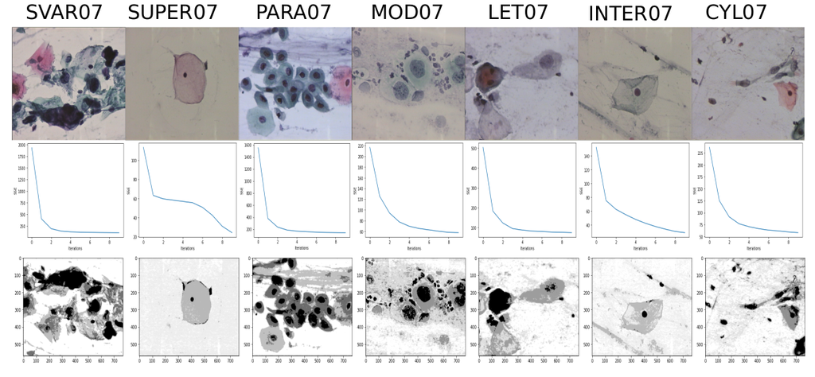

Compartion between original image (top),the Sum of Squared Errors plot (center) and result from the function (bottom)

## 3.3 Histogram thresholding: Otsu algorithm

**Histogram thresholding – single threshold that divides image into two segments: foreground (cells) and background (everything else).**

The function otsu_thresholding() is a threshold selection method for gray level histogram. This function returns a plot with a binarized image, an array called img_binary that can be used with other functions and a histogram with the distribution of the pixel values.

It is important to mention that the Otsu algorithm works best if the histogram of the image is bimodal, which, in most of the cases in the set of images given is not true.

The function takes two arguments:

- img: Name of the array inside the h5py file. The names of the images follow the notation image_tag.BMP e.g. image_svar99.BMP
- path_h5py_file: Directory file path where a h5py file is stored locally.

This function was build following [tutorial](https://theailearner.com/tag/otsu-method-opencv/)

```python
def otsu_thresholding(img, path_h5py_file = None):

    #Load h5py File
    hdf = h5py.File(f'{path_h5py_file}/cancerous_cell_smears.hdf5','r')
    for each_group in hdf:
        group = hdf.get(each_group)

        if img in set(group):
            img_array = np.array(group.get(img))[:,:,0]
            print(img_array)
            break

    # Set minimum value to infinity
    final_min = np.inf

    #Calculate hist for later use
    hist = plt.hist(img_array.ravel(),255,[0,255])
    plt.show()

    # total pixels in an image
    total = np.sum(hist[0])

    for each_bin in range(256):

        # Split regions based on threshold
        left, right = np.hsplit(hist[0],[each_bin])

        # Splt intensity values based on threshold
        left_bins, right_bins = np.hsplit(hist[1],[each_bin])

        # Only perform thresholding if neither side empty
        if np.sum(left) !=0 and np.sum(right) !=0:

            # Calculate weights on left and right sides
            w_0 = np.sum(left)/total
            w_1 = np.sum(right)/total

            # Calculate the mean for both sides
            mean_0 = np.dot(left,left_bins)/np.sum(left)
            # right_bins[:-1] because matplotlib has uses 1 bin extra
            mean_1 = np.dot(right,right_bins[:-1])/np.sum(right)

            # Calculate variance of both sides
            var_0 = np.dot(((left_bins-mean_0)**2),left)/np.sum(left)
            var_1 = np.dot(((right_bins[:-1]-mean_1)**2),right)/np.sum(right)

            # Calculate final within class variance
            final = w_0*var_0 + w_1*var_1

            # if variance minimum, update it
            if final < final_min:
                final_min = final
                thresh2 = each_bin

    #Make binary image available for other functions
    global img_binary

    # Get binary image
    img_binary = img_array
    img_binary[img_array > thresh2] = 255
    img_binary[img_array < thresh2] = 0

    #Invert image
    img_binary = np.invert(img_binary)

    #plot image
    plt.imshow(Image.fromarray(img_binary), cmap="gray")


#Test function-----------------------------------------------------------------
#path_h5py = '~/part_2'
#otsu_thresholding('image_cyl07.BMP', path_h5py_file = path_h5py)
```

## 3.4 Result Otsu

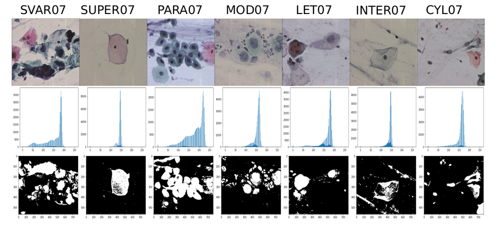

Compartion between original image (top), the distribution of the value of the pixels (center), and result from the function (bottom) (right)

# 4 Morphological operations: Erosion and dilation

**Implement dilation and erosion operators.**

For the erosion and dilation operator, I run the otsu_thresholding() function was first to obtain the binarized image.

## 4.1 Erosion

The function erode_imag eis a morphological operation that takes a binary image and returns a plot.

This function takes two arguments:

- img_array_binary: Is an array from of a binary image. The binary image can be obtain using the funtion called otsu_thresholding()
- erosion_level: Level of erosion desired

This function was build following this [tutorial]((https://medium.com/@ami25480/morphological-image-processing-operations-dilation-erosion-opening-and-closing-with-and-without-c95475468fca)

```python
@argh.arg('erosion_level',choices=[3,7,9,11])
def erode_image(image_array_binary, erosion_level = 3):


   m,n = image_array_binary.shape

    # Define the structuring element
    # k= 11,15,45 -Different sizes of the structuring element

   k = erosion_level
   se = np.ones((k,k), dtype=np.uint8)
   constant = (k-1)//2

    #Define new image
   img_erode = np.zeros((m,n), dtype=np.uint8)


   #Erosion operation
   for i in range(constant, m-constant):
       for j in range(constant,n-constant):
            temp = image_array_binary[i-constant:i+constant+1, j-constant:j+constant+1]
            product= temp*se
            img_erode[i,j] = np.min(product)

   plt.imshow(img_erode,cmap="gray")
```

## 4.2 Dilation

The function delation() is a morphological operation that takes a binary image and returns a plot.

This function takes one argument:

- img_array_binary: Is an array from of a binary image. The binary image can be obtain using the funtion called otsu_thresholding()

This function was build following this [tutorial]((https://medium.com/@ami25480/morphological-image-processing-operations-dilation-erosion-opening-and-closing-with-and-without-c95475468fca)

```python
def dilation_image(image_array_binary):

    p,q= image_array_binary.shape

    #Empty image with the size of the original
    img_dilate = np.zeros((p,q), dtype=np.uint8)

    #Kernel
    kernel = [[0,1,0], [1,1,1],[0,1,0]]


    #Dilation operation
    for i in range(1, p-1):
        for j in range(1, q-1):

            temp = image_array_binary[i-1 : i+1+1, j-1 : j + 1 + 1]
            product = temp * kernel
            img_dilate[i,j] = np.max(product)

    plt.imshow(img_dilate, cmap="gray")
```

## 4.3 Result Erosion and Dilation

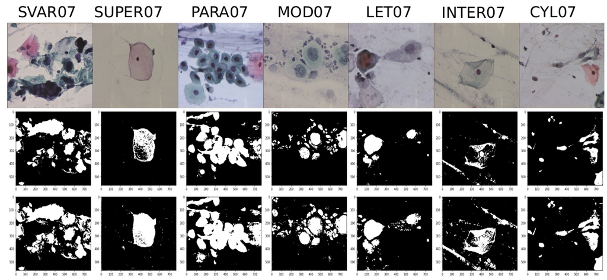

Compartion between original image (top), result from the function erosion (center) and result from the function dilation (bottom)